# Aula 3 - Gráficos

## Introdução

- Analisar um gráfico é uma maneira rápida e concisa de visualizar certas informações contidas em um conjunto de observações.
- O gráfico certo a ser utilizado em cada situação depende da informação que queremos visualizar e do tipo de variável que estamos trabalhando.
- Um gráfico mal muitas vezes falha em trazer com clareza a informação que queremos visualizar e, em alguns casos, pode levar a falsas evidências.

## Gráficos de barras

Amostra: estudantes de estatística (HairEyeColor)

X: cor do cabelo — Y: cor dos olhos — W: sexo

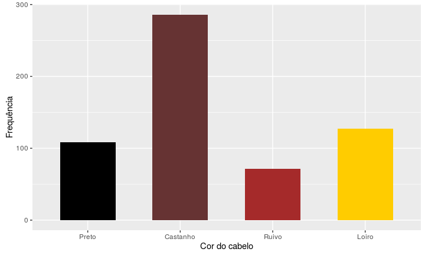

## Gráficos de barras

Podemos associar a variável "cor dos olhos" à cor das barras do gráfico.

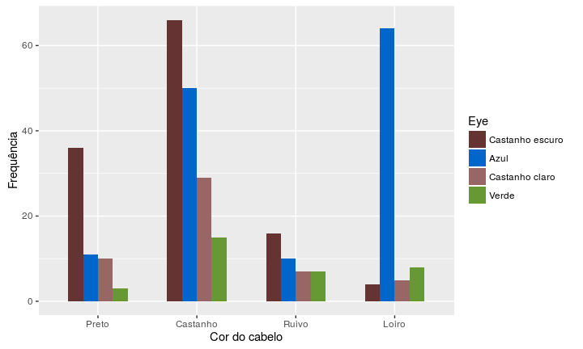

## Gráficos de barras

Além disso, podemos dividir o gráfico pela variável "sexo" e comparar as frequências para homens e mulheres.

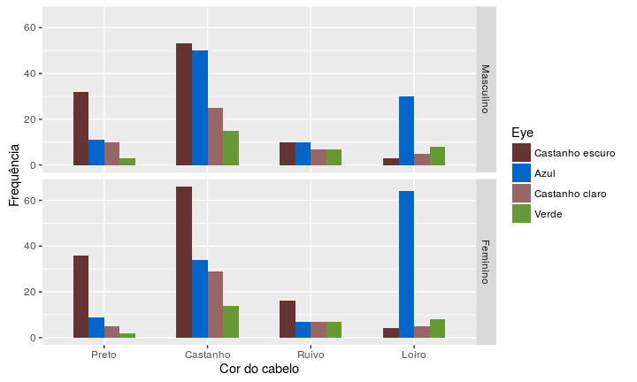

## Histogramas

Amostra de tamanho 400 de uma distribuição normal com média 170 e desvio padrão 8.

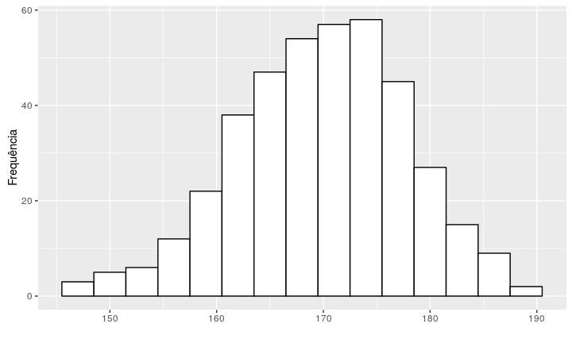

## Histogramas

Em vez de representar a frequência no eixo y, podemos optar pela densidade, definida pela razão entre a proporção e a amplitude de cada classe. Um histograma construído dessa forma tem área 1.

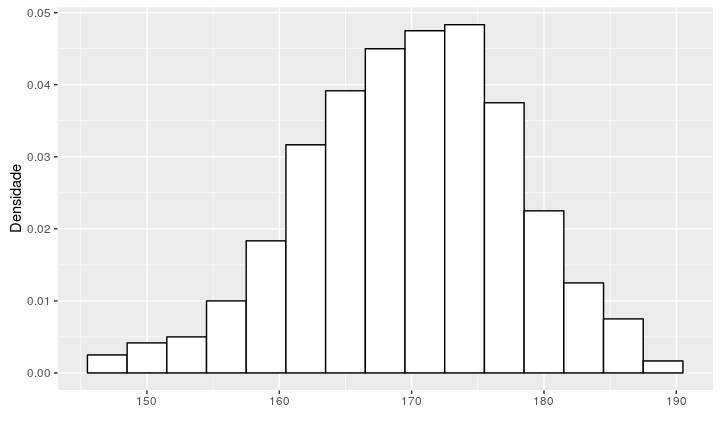

## Histogramas

Assimetria à direita

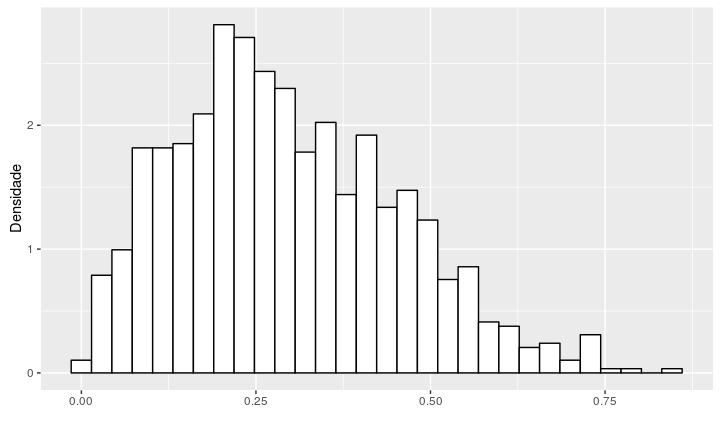

## Histogramas

Assimetria à esquerda

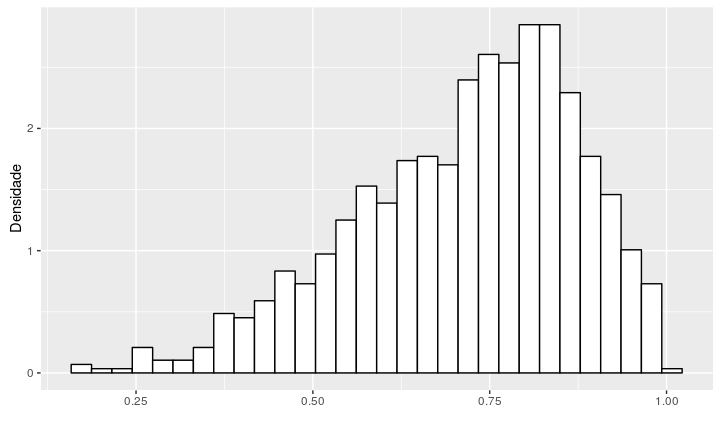

## Boxplots

Dados da temporada de Baseball de 1986, EUA (Baseball)

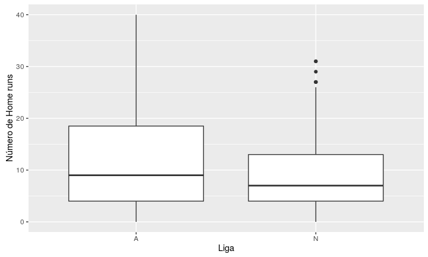

## Boxplots

Dados da temporada de Baseball de 1986, EUA

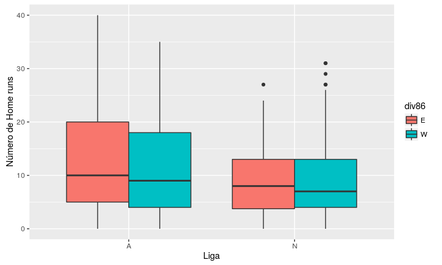

## Gráficos de dispersão

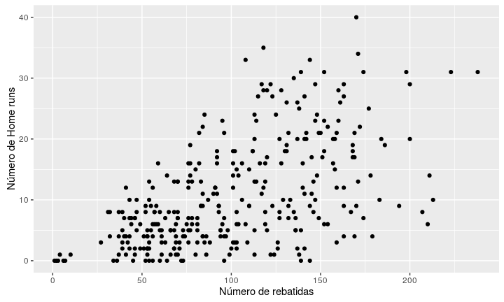

## Gráficos de dispersão

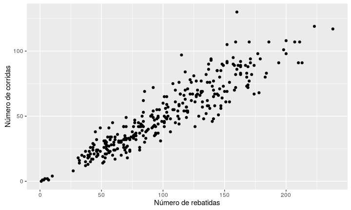

## Gráfico de uma série

Vazão do rio Nilo de 1871 a 1970 (Nile)

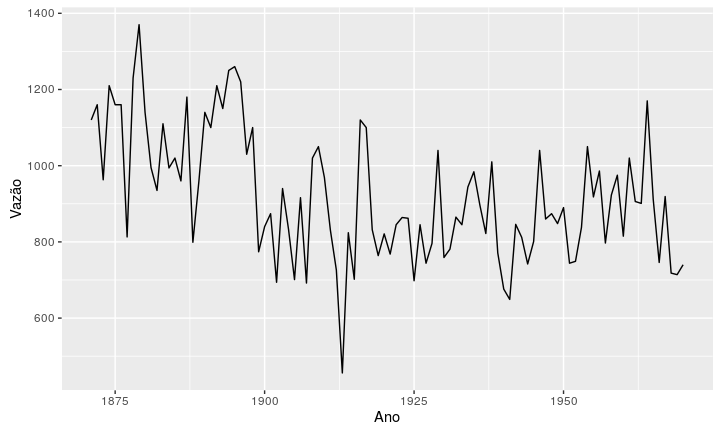

## Gráfico de uma série

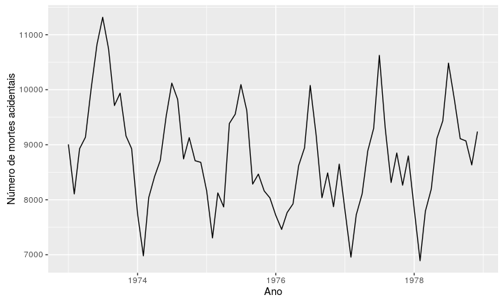

## Gráficos mal construídos

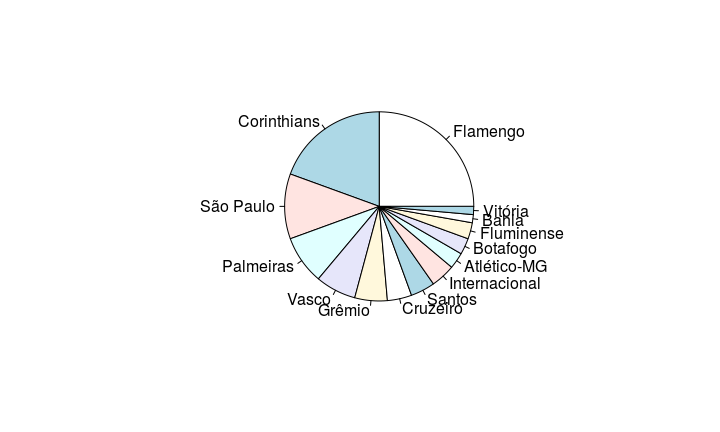

## Gráficos mal construídos

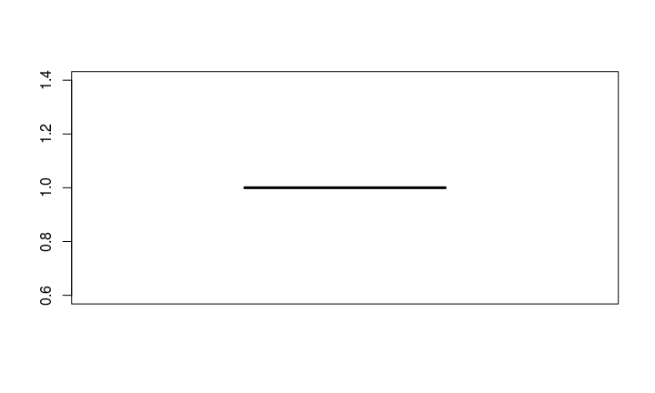

## Gráficos mal construídos

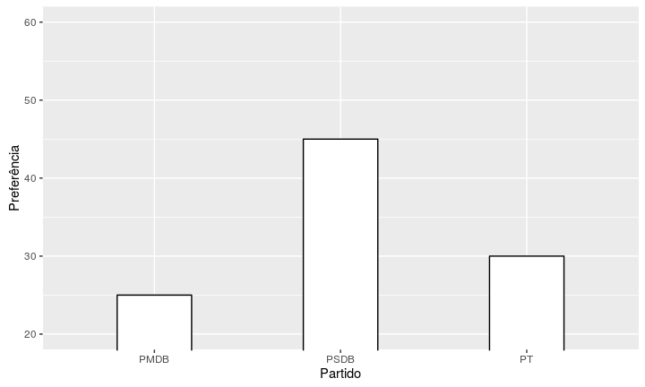

## Gráficos mal construídos

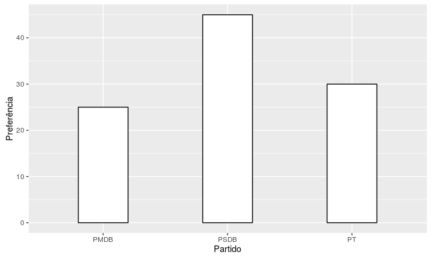